# Week 13 Independent Project

# 6. EXPLORATORY DATA ANALYSIS

## A. UNIVARIATE DATA ANALYSIS

### Measures of Central Tendency

#### i) Mean

```r
mean(advertising$"Daily Time Spent on Site")
```

```
## [1] 65.0002
```

The average time spent on the site daily is 65 minutes.

```r
mean(advertising$Age)
```

```
## [1] 36.009
```

The average age of individuals in our dataset is 36 years old.

```r
mean(advertising$"Daily Internet Usage")
```

```
## [1] 180.0001
```

The average daily internet usage is 180 units.

#### ii) Median

```r
median(advertising$"Daily Time Spent on Site")
```

```
## [1] 68.215
```

The median time spent on site daily is 68.215 minutes.

```r
median(advertising$Age)
```

```
## [1] 35
```

The median age is 35 years old.

```r
median(advertising$"Daily Internet Usage")
```

```
## [1] 183.13
```

The median daily internet usage is 183.13 units.

#### iii) Mode

```r
# Define a function for getting the mode
getmode <- function(v) {
  uniqv <- unique(v)
  uniqv[which.max(tabulate(match(v, uniqv)))]
}
getmode(advertising$"Daily Time Spent on Site")
```

```
## [1] 62.26
```

The mode for the daily time spent on the site is 62.26 minutes.

```r
getmode(advertising$Age)
```

```
## [1] 31
```

The mode for the age is 31 years old.

```r
getmode(advertising$"Daily Internet Usage")
```

```
## [1] 167.22
```

The mode for the daily internet usage is 167.22 units.

### Measures of Dispersion

#### i) Range

```r
range(advertising$"Daily Time Spent on Site")
```

```
## [1] 32.60 91.43
```

The range of daily time spent on the site is between 32.60 and 91.43 minutes

```r
range(advertising$Age)
```

```
## [1] 19 61
```

The age range is between 19 and 61 years old.

```r
range(advertising$"Daily Internet Usage")
```

```
## [1] 104.78 269.96
```

The range of daily internet usage is between 104.78 and 269.96 units.

#### ii) Quantiles

```r
quantile(advertising$"Daily Time Spent on Site")
```

```
##      0%     25%     50%     75%    100%
## 32.6000 51.3600 68.2150 78.5475 91.4300
```

The first quantile in the daily time spent is 51.36 minutes. The third quantile in the daily time spent on site is 78.55 minutes.

```r
quantile(advertising$Age)
```

```
##   0%  25%  50%  75% 100%
##   19   29   35   42   61
```

The first quantile in age is 29 years old. The third quantile in age is 42 years old.

```r
quantile(advertising$"Daily Internet Usage")
```

```
##       0%      25%      50%      75%     100%
## 104.7800 138.8300 183.1300 218.7925 269.9600
```

The first quantile in the daily internet usage is 138.83 units. The third quantile in the daily internet usage is 218.79 units.

#### iii) Variance

```r
var(advertising$"Daily Time Spent on Site")
```

```
## [1] 251.3371
```

The variance in the daily time spent on site is 251.33

```r
var(advertising$Age)
```

```
## [1] 77.18611
```

The variance in the age is 77.18

```r
var(advertising$"Daily Internet Usage")
```

```
## [1] 1927.415
```

The variance in the daily internet usage is 1927.415

#### iv) Standard Deviation

```r
sd(advertising$"Daily Time Spent on Site")
```

```
## [1] 15.85361
```

The standard deviation in the daily time spent on site is 15.85361

```r
sd(advertising$Age)
```

```
## [1] 8.785562
```

The standard deviation in the age is 8.785562

```r
sd(advertising$"Daily Internet Usage")
```

```
## [1] 43.90234
```

The standard deviation in the daily internet usage is 43.90234

### Frequency Tables

```r
# Gender Frequency Table
# 0 symbolizes female while 1 is male
gender <- table(advertising$Male)
gender
```

```
##
##   0   1
## 519 481
```

From the frequency table above, we can tell that there are 519 females and 481 males in our dataset.

```r
# Clicked on Ad Frequency Table
# 0 means the individual did not click on the ad, 1 means the individual clicked on an ad
clicked <- table(advertising$"Clicked on Ad")
clicked
```

```
##
##   0   1
## 500 500
```

From the frequency table above, we can tell that our dataset is balanced in the sense that 500 individuals clicked on the ad while 500 did not click on the ads.

```r
# Country Frequency Table
country <- (table(advertising$Country))

# Sort the table so as to find the country with the most individuals in our dataset
sorted_country <- sort(country, decreasing = TRUE)
head(sorted_country)
```

```
##
## Czech Republic         France    Afghanistan      Australia         Cyprus
##              9              9              8              8              8
##         Greece
##              8
```

From the frequency table above, we can tell that both Czech Republic and France had 9 individuals each while Afghanistan, Australia, Cyprus and Greece all had 8 individuals each.

```r
# City Frequency Table
city <- table(advertising$City)

# Sort the table so as to find the city with the most individuals in our dataset
sorted_city <- sort(city, decreasing = TRUE)
head(sorted_city)
```

```
##
##       Lisamouth    Williamsport Benjaminchester       East John    East Timothy
##               3               3               2               2               2
##        Johnstad
##               2
```

From the frequency table, we can tell that both Lisamouth and Williamsport both had 3 individuals each while Benjaminchester, East John, East Timothy and Johnstad all had 2 individuals each.

```r
# Age Frequency Table
age <- table(advertising$Age)

# Sort the table so as to find the age with the most individuals
sorted_age <- sort(age, decreasing = TRUE)
head(sorted_age)
```

```
##
## 31 36 28 29 33 30
## 60 50 48 48 43 39
```

From the frequency table, we can tell that individuals aged between 28 and 36 years old are the most in our dataset.

### Graphical Plots

#### i) Bar Charts

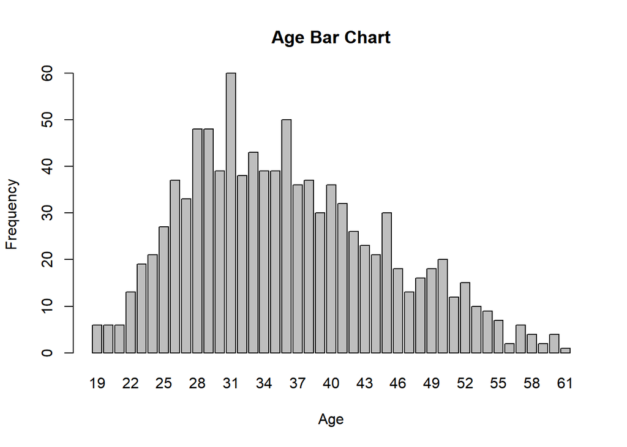

From the bar chart above, we can tell that age 31 had the highest frequency in the dataset.

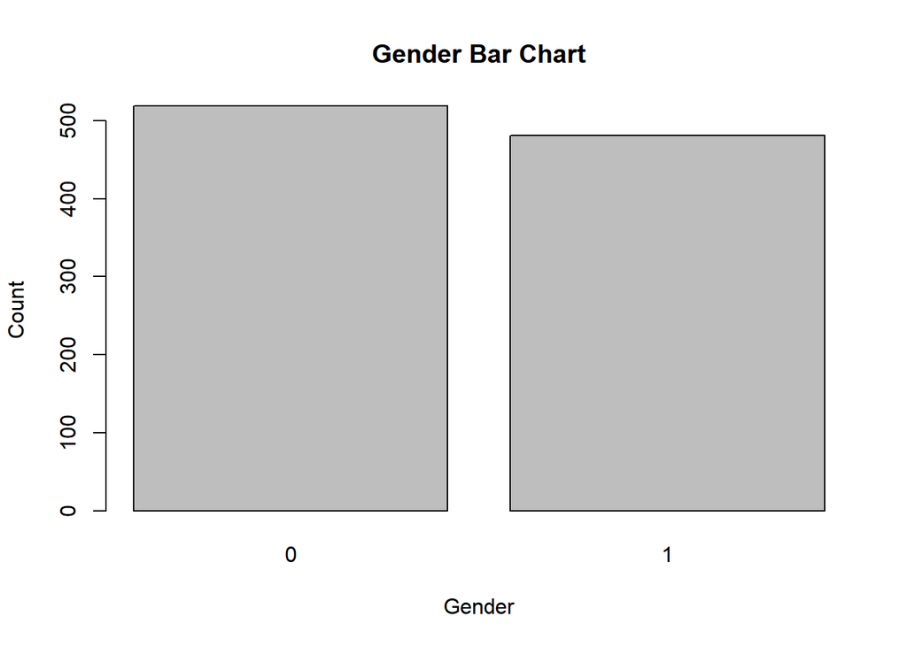

From the bar chart, we can tell that 0(female) had more count that 1(male) in our dataset.

#### ii) Histograms

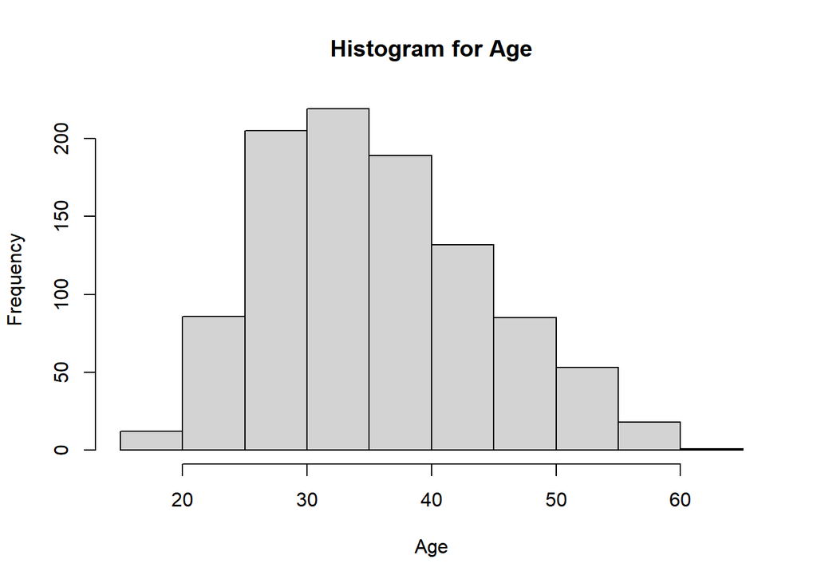

From the histogram, we can also tell that age 25 - 35 had the highest frequency in the dataset.

## B. BIVARIATE DATA ANALYSIS

### Covariance

```r
# We can find the covariance between age and the daily time spent on the site
age <- advertising$Age
time <- advertising$"Daily Time Spent on Site"

cov(age, time)
```

```
## [1] -46.17415
```

There is a negative covariance between age and the daily time spent on the site which means that the older a person is, the less time they spend on the site daily.

```r
age <- advertising$Age
units <- advertising$"Daily Internet Usage"

cov(age, units)
```

```
## [1] -141.6348
```

There is a negative covariance between age and the daily internet usage which means that the older a person is, the less units they use on internet daily.

```r
# Covariance between time spent on site and the daily internet usage
cov(time, units)
```

```
## [1] 360.9919
```

There is a positive covariance between the time spent on site and the daily internet usage which makes sense since the more time you spend on site, the higher your daily internet usage is bound to be.

### Correlation

```r
# We will use the age and time variables that we created earlier for correlation
cor(age, time)
```

```
## [1] -0.3315133
```

There is a negative linear relationship between age and the daily time spent on the site.

```r
# We will use the age and units variables that we created earlier for correlation
cor(age, units)
```

```
## [1] -0.3672086
```

There is a negative linear relationship between age and the daily internet usage.

```r
# Correlation between time spent on site and the daily internet usage
cor(time, units)
```

```
## [1] 0.5186585
```

There is a positive correlation between the time spent on site and the daily internet usage which makes sense since the more time you spend on site, the higher the amount of units you will use on internet.

### Correlation Matrix

First we load the corrplot library which enables us to plot a correlation matrix.

```r
library(corrplot) # This library allows us to plot correlation.
```

We go ahead to create a variable that holds the numerical columns in our dataset.

```r
# Create a subset of the numerical columns in our dataset
numerical <- subset(advertising, select = c("Daily Time Spent on Site", "Age", "Daily Internet Usage", "Area Income"))
```

Plot a correlation matrix for the numerical variables in our dataset.

```r
cor(numerical)
```

```
##                          Daily Time Spent on Site        Age
## Daily Time Spent on Site                1.0000000 -0.3315133
## Age                                    -0.3315133  1.0000000
## Daily Internet Usage                    0.5186585 -0.3672086
## Area Income                             0.3109544 -0.1826050
##                          Daily Internet Usage Area Income
## Daily Time Spent on Site            0.5186585   0.3109544
## Age                                -0.3672086  -0.1826050
## Daily Internet Usage                1.0000000   0.3374955
## Area Income                         0.3374955   1.0000000
```

### Scatter Plots

[figure not shown]

```r
# First we import the ggplot2 library which will help us in visualizations
library(ggplot2)
```

From the scatter plot we can tell that the longer the time spent on site, the higher the amount of units used on internet.

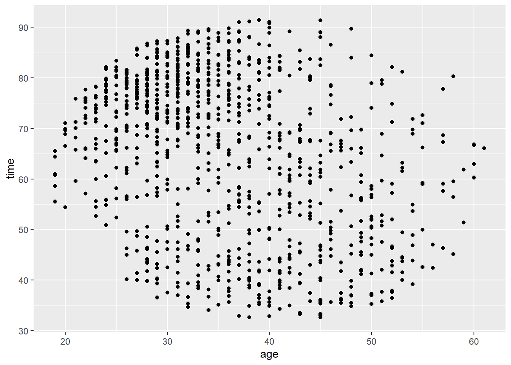

From the scatter plot, we can tell that the older an individual is, the less time spent on site.

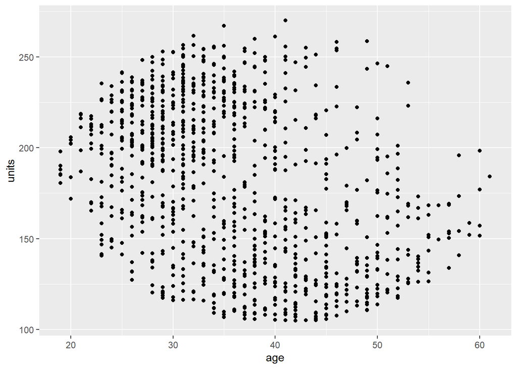

From this scatter plot, we can determine that the older an individual is, the lower the amount of units spent daily on internet.

# 7. IMPLEMENTING THE SOLUTION

We will implement the solution to our research problem by creating the following supervised learning models :

In this specific problem we will not use regression because our target variable is categorical and not continuous.

- First we perform label encoding to our categorical columns so as to enable modelling.

```r
# Import the library for label encoding
library(superml)
# Introduce the label encoder object
label <- LabelEncoder$new()

# Label encode the categorical columns i.e. City, Country
advertising$City <- label$fit_transform(advertising$City)
print(advertising$City)
```

[output not shown]

[output cut: 41 more lines]

```r
advertising$Country <- label$fit_transform(advertising$Country)
print(advertising$Country)
```

[output not shown]

[output cut: 41 more lines]

```r
print("Dataset after label encoding..\n")
```

```
## [1] "Dataset after label encoding..\n"
```

```r
print(advertising)
```

```
##       Daily Time Spent on Site Age Area Income Daily Internet Usage
##    1:                    68.95  35    61833.90               256.09
##    2:                    80.23  31    68441.85               193.77
##    3:                    69.47  26    59785.94               236.50
##    4:                    74.15  29    54806.18               245.89
##    5:                    68.37  35    73889.99               225.58
##   ---
##  996:                    72.97  30    71384.57               208.58
##  997:                    51.30  45    67782.17               134.42
##  998:                    51.63  51    42415.72               120.37
##  999:                    55.55  19    41920.79               187.95
## 1000:                    45.01  26    29875.80               178.35
##                               Ad Topic Line City Male Country
##    1:    Cloned 5thgeneration orchestration    0    0       0
##    2:    Monitored national standardization    1    1       1
```

[output cut: 21 more lines]

- After label encoding, we decide to drop the Timestamp and Ad Topic Line columns since we will not use them in modelling.

```r
Advertising = subset(advertising, select = c("Daily Time Spent on Site","Age","Area Income","Daily Internet Usage","City","Male","Country","Clicked on Ad"))
```

## 1. Naive Bayes

- We first try to understand the columns in our dataset.

```r
describe(Advertising)
```

```
##                          vars    n     mean       sd   median  trimmed      mad
## Daily Time Spent on Site    1 1000    65.00    15.85    68.22    65.74    17.92
## Age                         2 1000    36.01     8.79    35.00    35.51     8.90
## Area Income                 3 1000 55000.00 13414.63 57012.30 56038.94 13316.62
## Daily Internet Usage        4 1000   180.00    43.90   183.13   179.99    58.61
## City                        5 1000   477.87   280.44   473.50   476.80   359.53
## Male                        6 1000     0.48     0.50     0.00     0.48     0.00
## Country                     7 1000   108.92    64.96   107.00   107.78    81.54
## Clicked on Ad*              8 1000     1.50     0.50     1.50     1.50     0.74
##                               min      max    range  skew kurtosis     se
## Daily Time Spent on Site    32.60    91.43    58.83 -0.37    -1.10   0.50
## Age                         19.00    61.00    42.00  0.48    -0.41   0.28
## Area Income              13996.50 79484.80 65488.30 -0.65    -0.11 424.21
## Daily Internet Usage       104.78   269.96   165.18 -0.03    -1.28   1.39
## City                         0.00   968.00   968.00  0.03    -1.21   8.87
## Male                         0.00     1.00     1.00  0.08    -2.00   0.02
## Country                      0.00   236.00   236.00  0.11    -1.14   2.05
## Clicked on Ad*               1.00     2.00     1.00  0.00    -2.00   0.02
```

- We convert the target variable into a factor.

```r
Advertising$`Clicked on Ad` <- factor(Advertising$`Clicked on Ad`)
```

- We then check the first 6 records in our new dataframe.

```r
head(Advertising)
```

```
##    Daily Time Spent on Site Age Area Income Daily Internet Usage City Male
## 1:                    68.95  35    61833.90               256.09    0    0
## 2:                    80.23  31    68441.85               193.77    1    1
## 3:                    69.47  26    59785.94               236.50    2    0
## 4:                    74.15  29    54806.18               245.89    3    1
## 5:                    68.37  35    73889.99               225.58    4    0
## 6:                    59.99  23    59761.56               226.74    5    1
##    Country Clicked on Ad
## 1:       0             0
## 2:       1             0
## 3:       2             0
## 4:       3             0
## 5:       4             0
## 6:       5             0
```

- Split the data into training and test data sets

```r
indxTrain <- createDataPartition(y = advertising$`Clicked on Ad`, p = 0.7, list = FALSE)
training <- advertising[indxTrain,]
testing <- advertising[-indxTrain,]
```

- Checking the dimensions of the split sets

```r
prop.table(table(advertising$`Clicked on Ad`)) * 100
```

```
##
##  0  1
## 50 50
```

```r
prop.table(table(training$`Clicked on Ad`)) * 100
```

```
##
##  0  1
## 50 50
```

```r
prop.table(table(testing$`Clicked on Ad`)) * 100
```

```
##
##  0  1
## 50 50
```

- We then compare the outcomes of the training and testing phase by creating objects that will hold the predictor and response variables separately.

```r
x = training[, -8]
y = training$`Clicked on Ad`
```

- Loading our inbuilt e1071 package that holds the Naive Bayes function.

```r
library(e1071)
```

- Then we build our Naive Bayes model using our training data.

```r
model = naiveBayes(`Clicked on Ad` ~ ., data = training)
```

- Predicting the target variable using the testing data.

```r
y_pred = predict(model, newdata = testing)
```

- Create a table that holds the predicted and actual values

```r
confusion = table(testing$`Clicked on Ad`, y_pred)
```

- Evaluate the model using the confusion matrix() function which tells us the accuracy of the model.

```r
confusionMatrix(confusion)
```

```
## Confusion Matrix and Statistics
##
##    y_pred
##       0   1
##   0 143   7
##   1   0 150
##
##                Accuracy : 0.9767
##                  95% CI : (0.9525, 0.9906)
##     No Information Rate : 0.5233
##     P-Value [Acc > NIR] : < 2e-16
##
##                   Kappa : 0.9533
##
##  Mcnemar's Test P-Value : 0.02334
##
##             Sensitivity : 1.0000
##             Specificity : 0.9554
##          Pos Pred Value : 0.9533
##          Neg Pred Value : 1.0000
##              Prevalence : 0.4767
##          Detection Rate : 0.4767
##    Detection Prevalence : 0.5000
##       Balanced Accuracy : 0.9777
##
##        'Positive' Class : 0
##
```

## 2. KNN

- First we create a uniform distribution of 1000 rows.

```r
set.seed(1234)
# Randomize the rows and create a uniform distribution of 1000 rows
random <- runif(1000)
random
```

[output not shown]

[output cut: 185 more lines]

- Order the rows in our randomized dataset

```r
ad_random <- Advertising[order(random),]
```

- Preview the first 6 rows in our dataset

```r
head(ad_random)
```

```
##    Daily Time Spent on Site Age Area Income Daily Internet Usage City Male
## 1:                    80.46  29    56909.30               230.78  765    0
## 2:                    78.37  24    55015.08               207.27  466    0
## 3:                    57.99  50    62466.10               124.58  730    0
## 4:                    72.97  30    71384.57               208.58  965    1
## 5:                    77.66  29    67080.94               168.15  377    0
## 6:                    38.91  33    56369.74               150.80  357    1
##    Country Clicked on Ad
## 1:     222             0
## 2:     142             0
## 3:     113             1
## 4:      86             1
## 5:     178             0
## 6:     132             1
```

- Create a normalization function and normalize the response variables in our sampled dataset.

```r
normal <- function(x) (
  return( ((x - min(x)) /(max(x)-min(x))) )
)

normal(1:8)
```

```
## [1] 0.0000000 0.1428571 0.2857143 0.4285714 0.5714286 0.7142857 0.8571429
## [8] 1.0000000
```

```r
ad_new <- as.data.frame(lapply(ad_random[,-8], normal))
summary(ad_new)
```

```
##  Daily.Time.Spent.on.Site      Age          Area.Income
##  Min.   :0.0000           Min.   :0.0000   Min.   :0.0000
##  1st Qu.:0.3189           1st Qu.:0.2381   1st Qu.:0.5044
##  Median :0.6054           Median :0.3810   Median :0.6568
##  Mean   :0.5507           Mean   :0.4050   Mean   :0.6261
##  3rd Qu.:0.7810           3rd Qu.:0.5476   3rd Qu.:0.7860
##  Max.   :1.0000           Max.   :1.0000   Max.   :1.0000
##  Daily.Internet.Usage      City             Male          Country
##  Min.   :0.0000       Min.   :0.0000   Min.   :0.000   Min.   :0.0000
##  1st Qu.:0.2061       1st Qu.:0.2425   1st Qu.:0.000   1st Qu.:0.2203
##  Median :0.4743       Median :0.4892   Median :0.000   Median :0.4534
##  Mean   :0.4554       Mean   :0.4937   Mean   :0.481   Mean   :0.4615
##  3rd Qu.:0.6902       3rd Qu.:0.7451   3rd Qu.:1.000   3rd Qu.:0.6864
##  Max.   :1.0000       Max.   :1.0000   Max.   :1.000   Max.   :1.0000
```

- Create test and train data sets

```r
train <- ad_new[1:700,]
test <- ad_new[701:1000,]
train_label <- ad_random[1:700,8]
test_label <- ad_random[701:1000,8]
```

- Check the dimensions in our train sets

```r
dim(train_label)
```

```
## [1] 700   1
```

```r
dim(train)
```

```
## [1] 700   7
```

- We build our KNN model from the class library

```r
library(class)
require(class)
#cl = train_label[,1]
model <- knn(train = train, test = test, cl = train_label$`Clicked on Ad`, k=32)
table(factor(model))
```

```
##
##   0   1
## 160 140
```

```r
# Print out the confusion matrix
tb = table(test_label$`Clicked on Ad`,model)
tb
```

```
##    model
##       0   1
##   0 151   3
##   1   9 137
```

```r
# Checking the accuracy of our KNN model
accuracy <- function(x){sum(diag(x)/(sum(rowSums(x)))) * 100}
accuracy(tb)
```

```
## [1] 96
```

- We have achieved an accuracy score of 96% using the KNN model.

## 3. Support Vector Machine (SVM) Classifier

- First we encode the target feature into a factor

```r
# Encoding the target feature as factor
Advertising$`Clicked on Ad` = factor(Advertising$`Clicked on Ad`, levels = c(0, 1))
```

- We install the necessary package and then split the data in a 70/30 proportion so as to enable comparison with the other models.

```r
# Splitting the dataset into the Training set and Test set
#install.packages('caTools')
library(caTools)

set.seed(123)
split = sample.split(Advertising$`Clicked on Ad`, SplitRatio = 0.7)

training = subset(Advertising, split == TRUE)
test = subset(Advertising, split == FALSE)
```

- We then fit the SVM model to our training data.

```r
# Fitting SVM to the Training set

classifier = svm(formula = `Clicked on Ad` ~ .,
                data = training,
                type = 'C-classification',
                kernel = 'linear')
```

- We then predict using the testing set.

```r
# Predicting the Test set results
y_pred = predict(classifier, newdata = test)
```

- We then formulate the confusion matrix and check the accuracy based on the number of accurate predicted values.

```r
# Making the Confusion Matrix
cm = table(test$`Clicked on Ad`, y_pred)
```

```r
confusionMatrix(cm)
```

```
## Confusion Matrix and Statistics
##
##    y_pred
##       0   1
##   0 149   1
##   1   8 142
##
##                Accuracy : 0.97
##                  95% CI : (0.9438, 0.9862)
##     No Information Rate : 0.5233
##     P-Value [Acc > NIR] : <2e-16
##
##                   Kappa : 0.94
##
##  Mcnemar's Test P-Value : 0.0455
##
##             Sensitivity : 0.9490
##             Specificity : 0.9930
##          Pos Pred Value : 0.9933
##          Neg Pred Value : 0.9467
##              Prevalence : 0.5233
##          Detection Rate : 0.4967
##    Detection Prevalence : 0.5000
##       Balanced Accuracy : 0.9710
##
##        'Positive' Class : 0
##
```

- Using SVM, we achieve an accuracy score of 97%

## 4. Random Forest Classifier

- Install the packages necessary.

```r
# Installing package
install.packages("caTools")  # For sampling the dataset
install.packages("randomForest") # For implementing random forest algorithm
```

- Loading the package into our environment.

```r
# Loading package
library(caTools)
library(randomForest)
```

- Split the data in a 70/30 proportion.

```r
# Splitting data in train and test data
split <- sample.split(Advertising$`Clicked on Ad`, SplitRatio = 0.7)
split
```

[output not shown]

[output cut: 69 more lines]

```r
train <- subset(Advertising, split == "TRUE")
test <- subset(Advertising, split == "FALSE")
```

- Fit the random forest model to our training dataset.

```r
# Fitting Random Forest to the train dataset
set.seed(120) # Setting seed
classifier_RF = randomForest(x = train[,-8],
                            y = train$`Clicked on Ad`,
                            ntree = 500)

classifier_RF
```

```
##
## Call:
##  randomForest(x = train[, -8], y = train$`Clicked on Ad`, ntree = 500)
##                Type of random forest: classification
##                      Number of trees: 500
## No. of variables tried at each split: 2
##
##         OOB estimate of  error rate: 3.57%
## Confusion matrix:
##     0   1 class.error
## 0 340  10  0.02857143
## 1  15 335  0.04285714
```

- Make predictions on the test set.

```r
# Predicting the Test set results
y_pred = predict(classifier_RF, newdata = test)
```

- Evaluate using the confusion matrix.

```r
# Confusion Matrix
cm = table(test$`Clicked on Ad`, y_pred)
cm
```

```
##    y_pred
##       0   1
##   0 143   7
##   1   7 143
```

```r
confusionMatrix(cm)
```

```
## Confusion Matrix and Statistics
##
##    y_pred
##       0   1
##   0 143   7
##   1   7 143
##
##                Accuracy : 0.9533
##                  95% CI : (0.9229, 0.9743)
##     No Information Rate : 0.5
##     P-Value [Acc > NIR] : <2e-16
##
##                   Kappa : 0.9067
##
##  Mcnemar's Test P-Value : 1
##
##             Sensitivity : 0.9533
##             Specificity : 0.9533
##          Pos Pred Value : 0.9533
##          Neg Pred Value : 0.9533
##              Prevalence : 0.5000
##          Detection Rate : 0.4767
##    Detection Prevalence : 0.5000
##       Balanced Accuracy : 0.9533
##
##        'Positive' Class : 0
##
```

- Our Random Forest classifier gave us an accuracy score of 95.3%

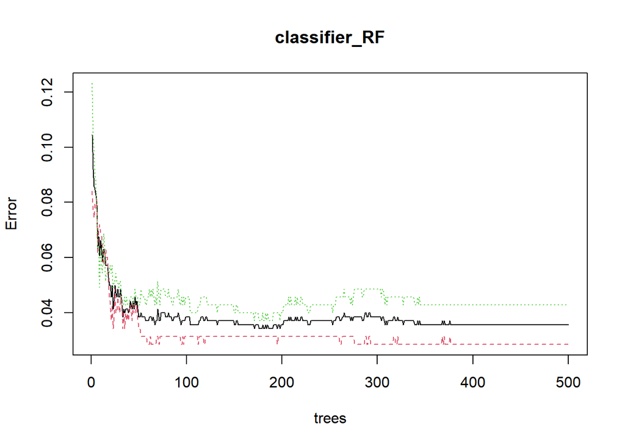

```r
# Plotting model
plot(classifier_RF)
```

- We then assess the most important features in our dataset.

```r
# Importance plot
importance(classifier_RF)
```

```
##                          MeanDecreaseGini
## Daily Time Spent on Site       104.062890
## Age                             35.294559
## Area Income                     40.274889
## Daily Internet Usage           148.719501
## City                            10.240562
## Male                             2.155433
## Country                          8.702659
```

From the feature importance table, we can tell that the most important features in our dataset are:

- Daily Internet Usage
- Daily Time Spent on Site
- Area Income
- Age

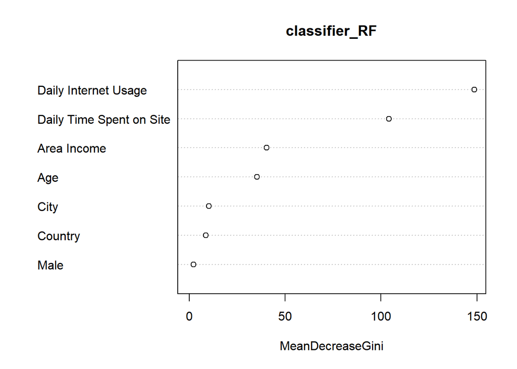

```r
# Variable importance plot
varImpPlot(classifier_RF)
```

# 8. CHALLENGING THE SOLUTION

- We decided to challenge the solution using the Logistic Regression Modeland then assess whether it will perform better than the other supervised learning algorithms.
- First we install the necessary package required.

```r
# Installing the package
#install.packages("caTools") # For Logistic regression
#install.packages("ROCR")    # For ROC curve to evaluate model
```

- Load the packages.

```r
# Loading package
library(caTools)
library(ROCR)
```

- Split the dataset in a 70/30 proportion for comparison purposes.

```r
# Splitting dataset
split <- sample.split(Advertising$`Clicked on Ad`, SplitRatio = 0.7)
split
```

[output not shown]

[output cut: 69 more lines]

- Initiate the training and test sets.

```r
training <- subset(Advertising, split == "TRUE")
test <- subset(Advertising, split == "FALSE")
```

- Train the logistic model using our training data.

```r
# Training model
logistic_model <- glm(`Clicked on Ad` ~ .,
                    data = training,
                    family = "binomial")
logistic_model
```

```
##
## Call:  glm(formula = `Clicked on Ad` ~ ., family = "binomial", data = training)
##
## Coefficients:
##                (Intercept)  `Daily Time Spent on Site`
##                 29.0935005                  -0.2171659
##                        Age               `Area Income`
##                  0.1863791                  -0.0001480
##     `Daily Internet Usage`                        City
##                 -0.0668572                   0.0001733
##                       Male                     Country
##                 -0.5590025                   0.0054096
##
## Degrees of Freedom: 699 Total (i.e. Null);  692 Residual
## Null Deviance:       970.4
## Residual Deviance: 104.3     AIC: 120.3
```

- Summary of the model.

```r
# Summary
summary(logistic_model)
```

```
##
## Call:
## glm(formula = `Clicked on Ad` ~ ., family = "binomial", data = training)
##
## Deviance Residuals:
##     Min       1Q   Median       3Q      Max
## -2.1737  -0.1065  -0.0183   0.0120   3.3477
##
## Coefficients:
##                              Estimate Std. Error z value Pr(>|z|)
## (Intercept)                 2.909e+01  3.827e+00   7.601 2.93e-14 ***
## `Daily Time Spent on Site` -2.172e-01  3.020e-02  -7.190 6.46e-13 ***
## Age                         1.864e-01  3.381e-02   5.513 3.53e-08 ***
## `Area Income`              -1.480e-04  2.506e-05  -5.906 3.51e-09 ***
## `Daily Internet Usage`     -6.686e-02  9.101e-03  -7.346 2.04e-13 ***
## City                        1.733e-04  1.056e-03   0.164     0.87
## Male                       -5.590e-01  5.508e-01  -1.015     0.31
## Country                     5.410e-03  4.606e-03   1.174     0.24
## ---
## Signif. codes:  0 '***' 0.001 '**' 0.01 '*' 0.05 '.' 0.1 ' ' 1
##
## (Dispersion parameter for binomial family taken to be 1)
##
##     Null deviance: 970.41  on 699  degrees of freedom
## Residual deviance: 104.32  on 692  degrees of freedom
## AIC: 120.32
##
## Number of Fisher Scoring iterations: 8
```

- Make predictions on the test data.

```r
# Predict test data based on model
predict_reg <- predict(logistic_model,
                    test, type = "response")
predict_reg
```

[output not shown]

[output cut: 45 more lines]

[output not shown]

- Changing probabilities.

```r
# Changing probabilities
predict_reg <- ifelse(predict_reg >0.5, 1, 0)
```

- Evaluate the performance of the model using the accuracy.

```r
# Evaluating model accuracy
# using confusion matrix
table(test$`Clicked on Ad`, predict_reg)
```

```
##    predict_reg
##       0   1
##   0 147   3
##   1   9 141
```

```r
missing_classerr <- mean(predict_reg != test$`Clicked on Ad`)
print(paste('Accuracy =', 1 - missing_classerr))
```

```
## [1] "Accuracy = 0.96"
```

# 8. CONCLUSIONS

From the univariate data analysis, we can conclude that:

- There were more females than males in our dataset.
- The dataset was balanced in the sense that 500 individuals clicked on the ads while 500 individuals did not click on the ads.
- Individuals who are between 28 and 36 years old were the most in our dataset.
- Czech Republic and France both had the highest number of individuals (9) in the dataset.
- Lisamouth and Williamsport cities both had the highest number of individuals (3) in the dataset.

From the bivariate data analysis, we can conclude that:

- There is a negative covariance and correlation between age and daily time spent on the site which means that the older an individual is, the less time they spend on the site.
- There is also a negative covariance and correlation between age and the daily internet usage which means that the younger an individual is, the higher the internet usage is as compared to an older individual.
- On the other hand, there is a positive covariance and correlation between the daily internet usage and the daily time spent on the internet.

# 9. RECOMMENDATIONS

- We recommend that she creates an ad that targets individuals aged between 25 and 35 years old seeing as they are the most in our dataset.
- We recommend that she focuses her attention more on the youth as they use the internet more and spend more time on the site as compared to the older individuals.